# Tema 6 - Intervalos de confianza

## Definiciones básicas

## Definición de intervalo de confianza

Intervalo de confianza. Dado un parámetro \(\theta\), el intervalo \((A,B)\) es un intervalo de confianza del \((1-\alpha)\cdot 100\)% para al parámetro \(\theta\) cuando \[ P(A<\theta<B)=1-\alpha. \] El valor \((1-\alpha)\cdot 100\)% (o contiene solo el \(1-\alpha\)) recibe el nombre de **nivel de confianza**.

El valor \(\alpha\) recibe el nombre de **nivel de significación**.

## Definición de intervalo de confianza

Por defecto, buscaremos intervalos bilaterales tales que la **cola de probabilidad sobrante** \(\alpha\) se reparta por igual a cada lado del intervalo: \[ P(\theta<A)=P(\theta>B)=\frac{\alpha}{2} \]

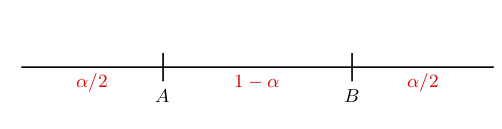

Por ejemplo, para buscar un intervalo de confianza \((A,B)\) del \(95\)%, buscaremos valores \(A,B\) de manera que \[ P(\theta<A)=0.025\quad\mbox{ y }\quad P(\theta>B)=0.025. \]

## Intervalos de confianza para el parámetro \(\mu\) de una población normal

## Intervalos de confianza para el parámetro \(\mu\) de una población normal con \(\sigma\) conocida

Teorema. Sea \(X\sim N(\mu,\sigma)\) con \(\mu\) desconocida y \(\sigma\) conocida.

Tomamos una m.a.s. de \(X\) de tamaño \(n\), con media \(\overline{X}\).

Un intervalo de confianza del \((1-\alpha)\cdot 100\)% para \(\mu\) es \[ \left(\overline{X} -z_{1-\frac{\alpha}{2}} \frac{\sigma}{\sqrt{n}}, \overline{X}+z_{1-\frac{\alpha}{2}}\frac{\sigma}{\sqrt{n}} \right) \] donde \(z_{1-\frac{\alpha}{2}}\) es el \((1-\frac{\alpha}{2})\)-cuantil de la normal estándar \(Z\) (es decir, \(z_{1-\frac{\alpha}{2}}=F_Z^{-1}(1-\frac{\alpha}{2})\), o \(P(Z\leq z_{1-\frac{\alpha}{2}})=1-\frac{\alpha}{2}\)).

## Intervalos de confianza para el parámetro \(\mu\) de una población normal con \(\sigma\) conocida

Si \(X\) es normal con \(\sigma\) conocida, un intervalo de confianza I.C. para \(\mu\) de población normal con \(\sigma\) conocida \(\mu\) del \((1-\alpha)\cdot 100\)% es \[ \overline{X} \pm z_{1-\frac{\alpha}{2}} \frac{\sigma}{\sqrt{n}}:=\left(\overline{X} -z_{1-\frac{\alpha}{2}} \frac{\sigma}{\sqrt{n}}, \overline{X}+z_{1-\frac{\alpha}{2}}\frac{\sigma}{\sqrt{n}}. \right) \] Observad que está centrado en \(\overline{X}\).

## Intervalos de confianza para el parámetro \(\mu\) de una población normal con \(\sigma\) conocida

La tabla siguiente muestra los cuantiles más usados:

[output not shown]

## Simulación de intervalos de confianza

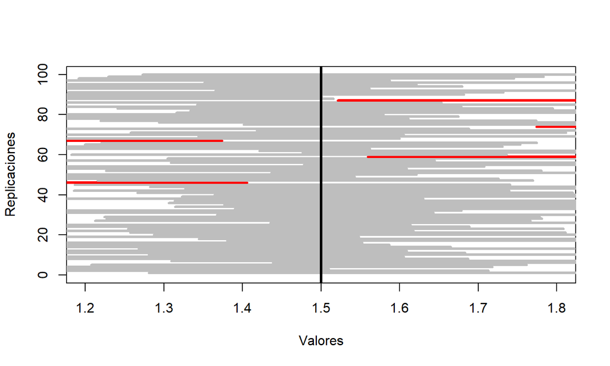

## Amplitud y error máximo

Amplitud del intervalo de confianza. La amplitud \(A\) del intervalo de confianza a un nivell \(100\cdot (1-\alpha)\)% de confianza será: \[ A = \overline{X}+ z_{1-\frac{\alpha}{2}}\frac{\sigma}{\sqrt{n}}-\Big(\overline{X} -z_{1-\frac{\alpha}{2}}\frac{\sigma}{\sqrt{n}}\Big)= 2\cdot z_{1-\frac{\alpha}{2}}\frac{\sigma}{\sqrt{n}}. \]

Error máximo cometido. El error máximo, al nivel de confianza \(100\cdot (1-\alpha)\)%, que cometemos al estimar \(\mu\) por \(\overline{X}\) es la mitad de la amplitud,

\[ z_{1-\frac{\alpha}{2}}\frac{\sigma}{\sqrt{n}}. \]

## Amplitud y error máximo

Propiedades

- La **amplitud** del intervalo de confianza para el parámetro \(\mu\) de una población normal con \(\sigma\) conocida, \(n\) y \(\alpha\) fijos **crece**, si **\(\sigma\) crece**.
- La **amplitud** del intervalo de confianza para el parámetro \(\mu\) de una población normal con \(\sigma\) conocida y \(\alpha\) fijo **decrece**, si **\(n\) crece**.
- La **amplitud** del intervalo de confianza para el parámetro \(\mu\) de una población normal con \(\sigma\) conocida y \(n\) fijo **crece**, si **\(1-\alpha\) crece**, o si **\(\alpha\) decrece**.

## Amplitud y error máximo

Problema: hallar el tamaño \(n\) mínimo de la muestra para asegurar que el intervalo de confianza para \(\mu\) al nivel de confianza \((1-\alpha)\) tenga una amplitud prefijada máxima \(A_0\) (o un error máximo \(A_0/2\)).

Resolución: usando que la amplitud máxima tiene que ser \(A_0\) tenemos que se tiene que verificar \(A_0\geq 2z_{1-\frac{\alpha}{2}}\frac{\sigma}{\sqrt{n}}\).

Despejando \(n\) de la expresión anterior, tendremos que el tamaño de la muestra mínimo será: \[ n\geq \left( 2 z_{1-\frac{\alpha}{2}}\frac{\sigma}{A_0}\right)^2. \]

## Intervalos de confianza para el parámetro \(\mu\) de una población normal con \(\sigma\) desconocida

Recordemos que para hallar el intervalo de confianza para el parámetro \(\mu\) de una población normal, era clave la variable aleatoria \(\frac{\overline{X}-\mu}{\sigma/\sqrt{n}}.\)

El problema es que ahora no la podemos usar al no conocer \(\sigma\).

Lo que haremos será sustituir la desviación típica poblacional \(\sigma\) por la desviación típica muestral \(\widetilde{S}_{X}\) y nos quedará: \(\frac{\overline{X}-\mu}{\widetilde{S}_{X}/\sqrt{n}},\) donde \(\overline{X}\) es la media muestral y \(n\), el tamaño de la muestra.

## Intervalos de confianza para el parámetro \(\mu\) de una población normal con \(\sigma\) desconocida

La distribución de la variable anterior \(\frac{\overline{X}-\mu}{\widetilde{S}_{X}/\sqrt{n}},\) no será normal sino \(t\) de Student con \(n-1\) grados de libertad como nos dice el teorema siguiente:

Teorema. Sea \(X\sim N(\mu,\sigma)\). Sea \(X_1,\ldots,X_n\) una m.a.s. de \(X\), con media \(\overline{X}\) y desviación típica muestral \(\widetilde{S}_{X}\)

En estas condiciones, la v.a. \(t=\frac{\overline{X}-\mu}{\widetilde{S}_{X}/\sqrt{n}},\) sigue una distribución \(t\) de Student con \(n-1\) grados de libertad, \(t_{n-1}\).

## Distribución \(t\) de Student

La distribución \(t\) de Student con \(\nu\) grados de libertad, \(t_{\nu}\) tiene como función de densidad \[ f_{t_\nu}(x) = \frac{\Gamma(\frac{\nu+1}{2})} {\sqrt{\nu\pi}\,\Gamma(\frac{\nu}{2})} \Big(1+\frac{x^2}{\nu} \Big)^{-\frac{\nu+1}{2}}, \] donde \(\Gamma(x)=\int_{0}^{\infty} t^{x-1}e^{-t}\, dt\) si \(x> 0\).

## Distribución \(t\) de Student

Propiedades

- \(E(t_{\nu})=0\) si \(\nu>1\) y \(Var(t_{\nu})=\dfrac{\nu}{\nu-2}\) si \(\nu>2\).
- Su función de distribución es simétrica respecto de \(E(t_{\nu})=0\) (como la de una \(N(0,1)\)): \[ P(t_{\nu}\leq -x)=P(t_{\nu}\geq x)=1-P(t_{\nu}\leq x). \]
- Si \(\nu\) es grande, su distribución es aproximadamente la de \(N(0,1)\) (pero con más varianza: un poco más aplastada)

## Distribución \(t\) de Student

Gráficas de las densidades de diferentes distribuciones \(t\) de Student junto con la densidad de la \(N(0,1)\):

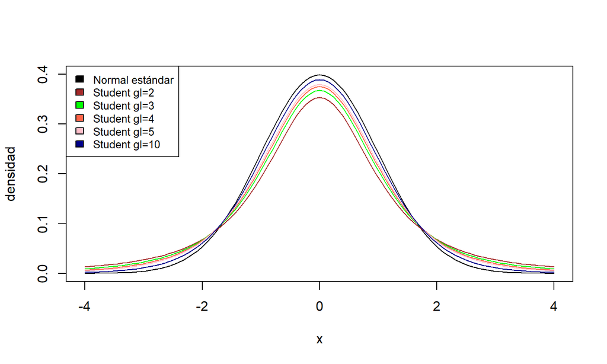

## Distribución \(t\) de Student

Indicaremos con \(t_{\nu,q}\) el \(q\)-cuantil de una v.a. \(X\) que sigue una distribución \(t_\nu\): \[ P(X\leq t_{\nu,q})=q \]

Por simetría, \(t_{\nu,q}=-t_{\nu,1-q}\).

## Intervalos de confianza para el parámetro \(\mu\) de una población normal con \(\sigma\) desconocida

Consideremos la situación siguiente:

- \(X\) una v.a. normal con \(\mu\) y \(\sigma\) desconocidas.
- \(X_1,\ldots,X_n\) una m.a.s. de \(X\) de tamaño \(n\), con media \(\overline{X}\) y varianza muestral \(\widetilde{S}_X^2\).

Intervalo de confianza para el parámetro \(\mu\). En estas condiciones, un intervalo de confianza del \((1-\alpha)\cdot 100\)% para el parámetro \(\mu\) de una población normal con \(\sigma\) desconocida es \[ \left( \overline{X}-t_{n-1,1-\frac{\alpha}{2}} \frac{\widetilde{S}_{X}}{\sqrt{n}}, \overline{X}+t_{n-1,1-\frac{\alpha}{2}}\frac{\widetilde{S}_{X}}{\sqrt{n}} \right). \]

## Intervalos de confianza para el parámetro \(\mu\) de una población cualquiera con \(\sigma\) conocida y tamaño muestral grande

En estas condiciones, usando el **Teorema Central del Límite** \(\frac{\overline{X}-\mu}{\frac{\sigma}{\sqrt{n}}}\approx N(0,1)\).

Teorema. En las condiciones anteriores, podemos tomar como intervalo de confianza del \((1-\alpha)\cdot 100\%\) de confianza para el parámetro \(\mu\) de una población cualquiera con \(\sigma\) conocida la expresión siguiente: \[ \left(\overline{X}-z_{1-\frac{\alpha}{2}}\frac{\sigma}{\sqrt{n}}, \overline{X}+z_{1-\frac{\alpha}{2}}\frac{\sigma}{\sqrt{n}}\right) \]

## Intervalos de confianza para el parámetro \(\mu\) de una población cualquiera con \(\sigma\) desconocida y tamaño muestral grande

Si la \(\sigma\) es desconocida, podemos aplicar el Teorema anterior sustituyendo \(\sigma\) por \(\widetilde{S}_X\):

Teorema. En las condiciones anteriores, podemos tomar como intervalo de confianza del \((1-\alpha)\cdot 100\%\) de confianza para el parámetro \(\mu\) de una población cualquiera con \(\sigma\) desconocida la expresión siguiente: \[ \left(\overline{X}-z_{1-\frac{\alpha}{2}}\frac{\widetilde{S}_X}{\sqrt{n}}, \overline{X}+z_{1-\frac{\alpha}{2}}\frac{\widetilde{S}_X}{\sqrt{n}}\right) \]

## Intervalos de confianza para el parámetro \(p\) de una población de Bernoulli

## Método de Laplace

Consideremos la situación siguiente :

- \(X\) una v.a. Bernoulli con \(p\) desconocida.
- \(X_1,\ldots,X_n\) una m.a.s. de \(X\), con \(n\) grande (por Ejemplo, \(n\geq 40\)) y frecuencia relativa de éxitos \(\widehat{p}_{X}\).

En estas condiciones (por el Teorema Central del Límite), \[ Z=\dfrac{\widehat{p}_{X}-p} {\sqrt{\frac{p(1-p)}{n}}}\approx N(0,1) \]

## Caso del tamaño \(n\) de la muestra grande

Por lo tanto

\[ P\left(-z_{1-\frac{\alpha}{2}}\leq \dfrac{\widehat{p}_{X}-p} {\sqrt{\frac{p(1-p)}{n}}}\leq z_{1-\frac{\alpha}{2}}\right)=1-\alpha. \]

El problema es que no conocemos \(p\)…

La literatura plantea otras soluciones como por ejemplo la fórmula de Laplace (1812)

## Fórmula de Laplace.

Supongamos que la proporción muestral de éxitos \(\widehat{p}_{X}\) está alejada de 0 y de 1.

- Es decir, \(n\geq 100\) y que \(n\widehat{p}_{X}\geq 10\) y \(n(1-\widehat{p}_{X})\geq 10\).
- En este caso, podemos usar la fórmula de **Laplace**: \[ \widehat{p}_{X}\pm z_{1-\alpha/2}\sqrt{\frac{\widehat{p}_{X} (1-\widehat{p}_{X})}{n}}. \]

## Fórmula de Laplace. Amplitud

Problema: hallar el tamaño de la muestra fijada la amplitud del intervalo de confianza.

La **amplitud** del intervalo de confianza usando la fórmulade Laplace es \[ A=2 z_{1-\frac{\alpha}{2}} \sqrt{\frac{\widehat{p}_{X} (1-\widehat{p}_{X})}{n}}. \]

No podemos determinar el tamaño de la muestra para que el intervalo de confianza tenga como máximo una cierta amplitud sin conocer \(\widehat{p}_{X}\).

Vamos a considerar que estamos en el peor de los casos.

O sea, usando que \(\widehat{p}_{X}\in [0,1]\), nos planteamos hallar el máximo de la expresión \(\widehat{p}_{X} (1-\widehat{p}_{X})\) que aparece en la fórmula de la amplitud.

## Fórmula de Laplace. Amplitud

El máximo de la función anterior, para \(\widehat{p}_{X}\in [0,1]\) se alcanza en \(\widehat{p}_{X}=\frac{1}{2}\) y dicho máximo vale \(\frac{1}{4}\):

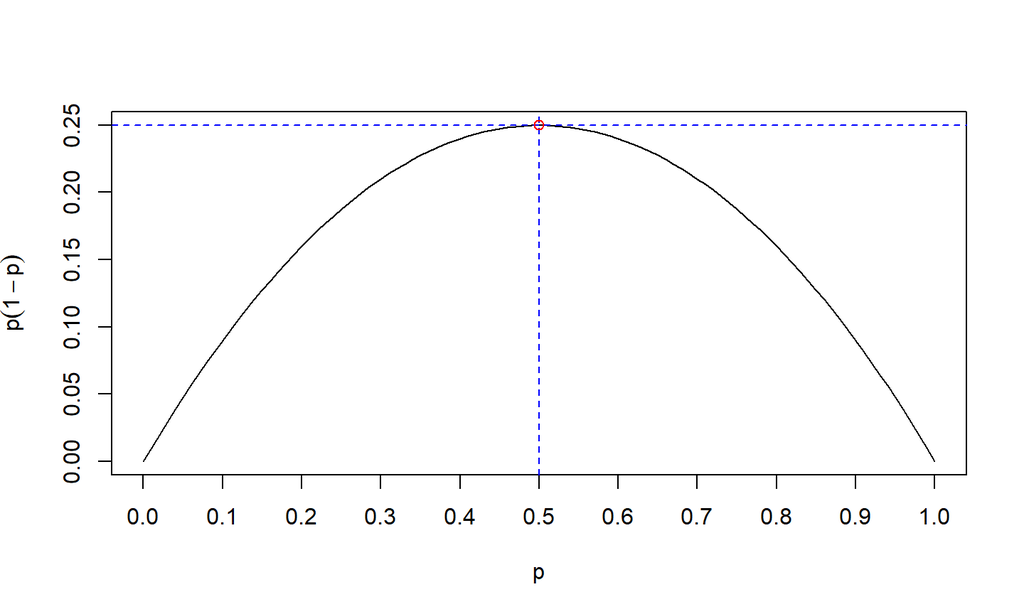

## Fórmula de Laplace. Amplitud

En resumen, calcularemos \(n\) para obtener una amplitud máxima \(A_0\) suponiendo el peor de los casos (\(\widehat{p}_{X}=0.5\)): \[ A_0\geq 2z_{1-\frac{\alpha}{2}}\sqrt{\frac{0.5^2}{n}}=\frac{z_{1-\frac{\alpha}{2}}}{\sqrt{n}} \Rightarrow n\geq \left\lceil\frac{z_{1-\frac{\alpha}{2}}^2}{A_0^2}\right\rceil. \]

## Intervalo de confianza para la varianza de una población normal

## Intervalo de confianza para la varianza de una población normal

Consideremos la siguiente situación:

- Consideramos una \(X\) una v.a. normal con \(\mu\) y \(\sigma\) desconocidas.
- Sea \(X_1,\ldots,X_n\) una m.a.s. de \(X\) y varianza muestral \(\widetilde{S}_X^2\).

En estas condiciones tenemos el siguiente:

Teorema.

La variable aleatoria \(\frac{(n-1) \tilde{S}_{X}^2}{\sigma^2}\) se distribuye según una distribución \(\chi^2_{n-1}\).

## Intervalo de confianza para la varianza de una población normal

Teorema.

En las condiciones anteriores, un intervalo de confianza del \((1-\alpha)\cdot 100\%\) para la varianza \(\sigma^2\) de la población \(X\) es \[ \left( \frac{(n-1)\widetilde{S}_{X}^2}{\chi_{n-1,1-\frac{\alpha}{2}}^2}, \frac{(n-1)\widetilde{S}_{X}^2}{\chi_{n-1,\frac{\alpha}{2}}^2} \right), \] donde \(\chi_{\nu,q}^2\) es el \(q\)-cuantil de la distribución \(\chi_{\nu}^2\).

## Bootstrap o remuestreo

## Técnicas de remuestreo

Cuando no se satisfacen las condiciones teóricas que garantizan que el intervalo obtenido contiene el 95% de las veces el parámetro poblacional deseado, podemos recurrir a un método no paramétrico. El más utilizado es el **bootstrap**, que básicamente consiste en:

1. **Remuestrear** la muestra: tomar muchas muestras aleatorias simples de la muestra de la que disponemos, cada una de ellas del mismo tamaño que la muestra original (pero simples, es decir, con reposición).
2. Calcular el estimador sobre cada una de estas submuestras.
3. Organizar los resultados en un vector.
4. Usar este vector para calcular un intervalo de confianza.

## Bootstrap: método de los percentiles

La manera más sencilla de llevar a cabo el cálculo final del intervalo de confianza es el llamado **método de los percentiles** , en el que se toman como extremos del intervalo de confianza del \((1-\alpha)\cdot 100%\) los cuantiles de orden \(\frac{\alpha}{2}\) y \(1-\frac{\alpha}{2}\) del vector de estimadores.